# COMPSCIX 415.2 Homework 7

## Q2: Visualize the covariation between SalePrice and Neighborhood.

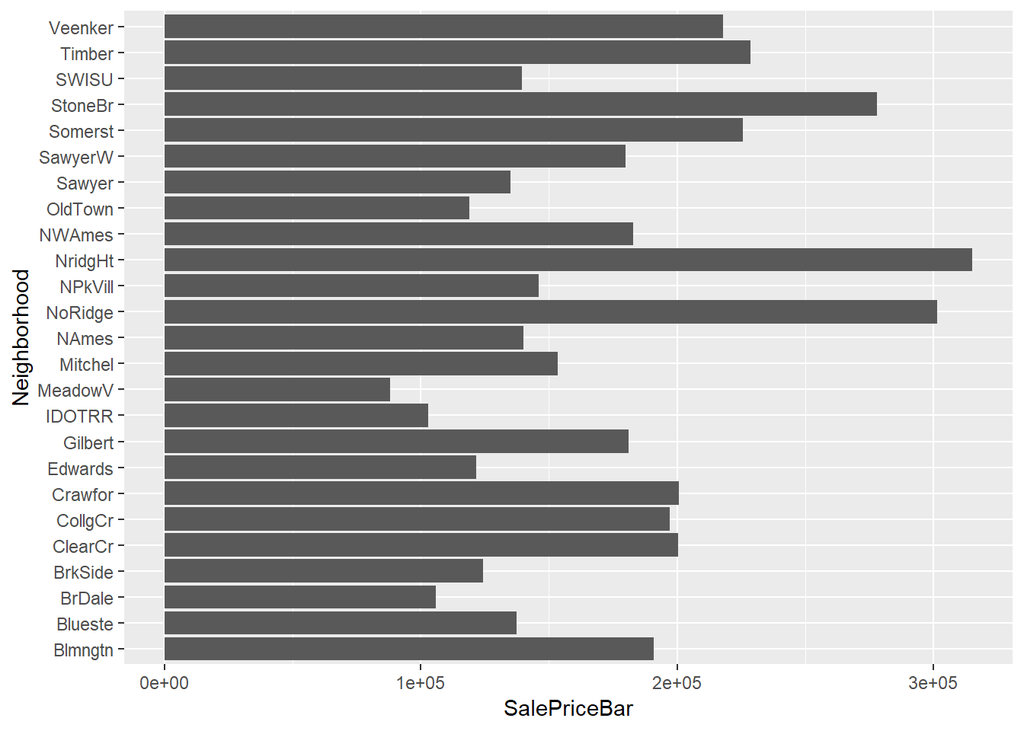

```r
neighbour_price <- train_data %>%
  group_by(Neighborhood) %>%
  summarise(SalePriceBar = median(SalePrice, na.rm = TRUE)) %>%
  arrange(desc(SalePriceBar))
ggplot(neighbour_price) +
  geom_col(aes(Neighborhood, SalePriceBar)) +
  coord_flip()
```

## Q3: Visualize the covariation between SalePrice and OverallQual

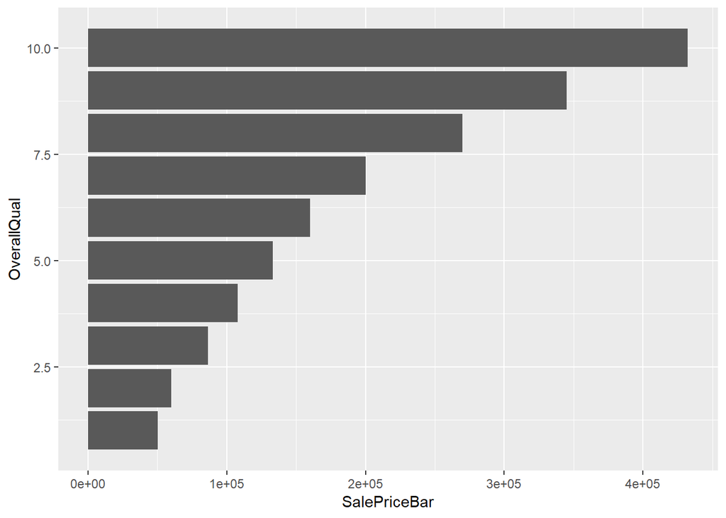

```r
quality_price <- train_data %>%
  group_by(OverallQual) %>%
  summarise(SalePriceBar = median(SalePrice, na.rm = TRUE))
ggplot(quality_price) +
  geom_col(aes(OverallQual, SalePriceBar)) +
  coord_flip()
```

# Exercise 3:

Fit the model and then use the broom package

## Q1: take a look at the coefficient

```r
(train.lm <- lm(formula = SalePrice ~ OverallQual, data = train_data))
```

```
##
## Call:
## lm(formula = SalePrice ~ OverallQual, data = train_data)
##
## Coefficients:
## (Intercept)  OverallQual
##      -96206        45436
```

```r
tidy(train.lm)
```

```
## # A tibble: 2 x 5
##   term        estimate std.error statistic   p.value
##   <chr>          <dbl>     <dbl>     <dbl>     <dbl>
## 1 (Intercept)  -96206.     5756.     -16.7 1.67e- 57
## 2 OverallQual   45436.      920.      49.4 2.19e-313
```

Answer: Coefficient is 45436.

## Q2: compare the coefficient to the average value of SalePrice

```r
mean(train_data$SalePrice)
```

```
## [1] 180921.2
```

```r
train.lm
```

```
##
## Call:
## lm(formula = SalePrice ~ OverallQual, data = train_data)
##
## Coefficients:
## (Intercept)  OverallQual
##      -96206        45436
```

Answer: Coeffiicient (45436) is much smaller than Average SalePrice (180921)

## Q3: Take a look at the R-squared

```r
glance(train.lm)
```

```
## # A tibble: 1 x 11
##   r.squared adj.r.squared  sigma statistic   p.value    df  logLik    AIC
##       <dbl>         <dbl>  <dbl>     <dbl>     <dbl> <int>   <dbl>  <dbl>
## 1     0.626         0.625 48623.     2437. 2.19e-313     2 -17827. 35659.
## # ... with 3 more variables: BIC <dbl>, deviance <dbl>, df.residual <int>
```

Answer: The R-squared is 0.6256519

# Exercise 4:

Now fit a linear regression model using GrLivArea, OverallQual, and Neighborhood as the features.

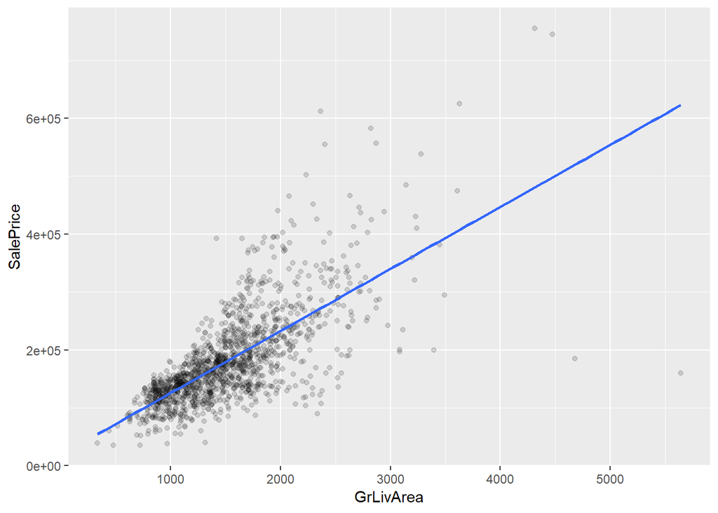

```r
data(train_data)

ggplot(train_data) +
  geom_point(aes(GrLivArea, SalePrice), alpha = .15) +
  geom_smooth(aes(GrLivArea, SalePrice), method = "lm", se = FALSE)
```

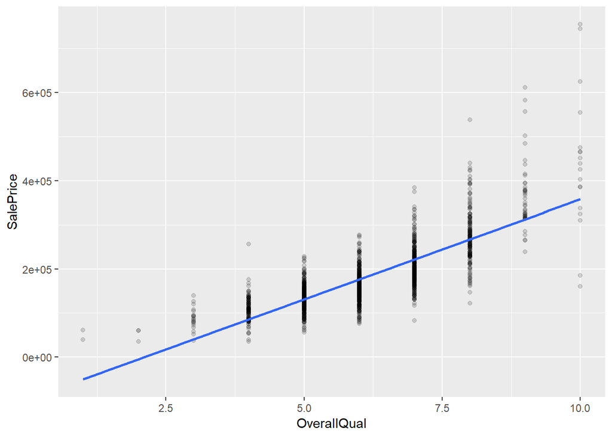

```r
ggplot(train_data) +
  geom_point(aes(OverallQual, SalePrice), alpha = .15) +
  geom_smooth(aes(OverallQual, SalePrice), method = "lm", se = FALSE)
```

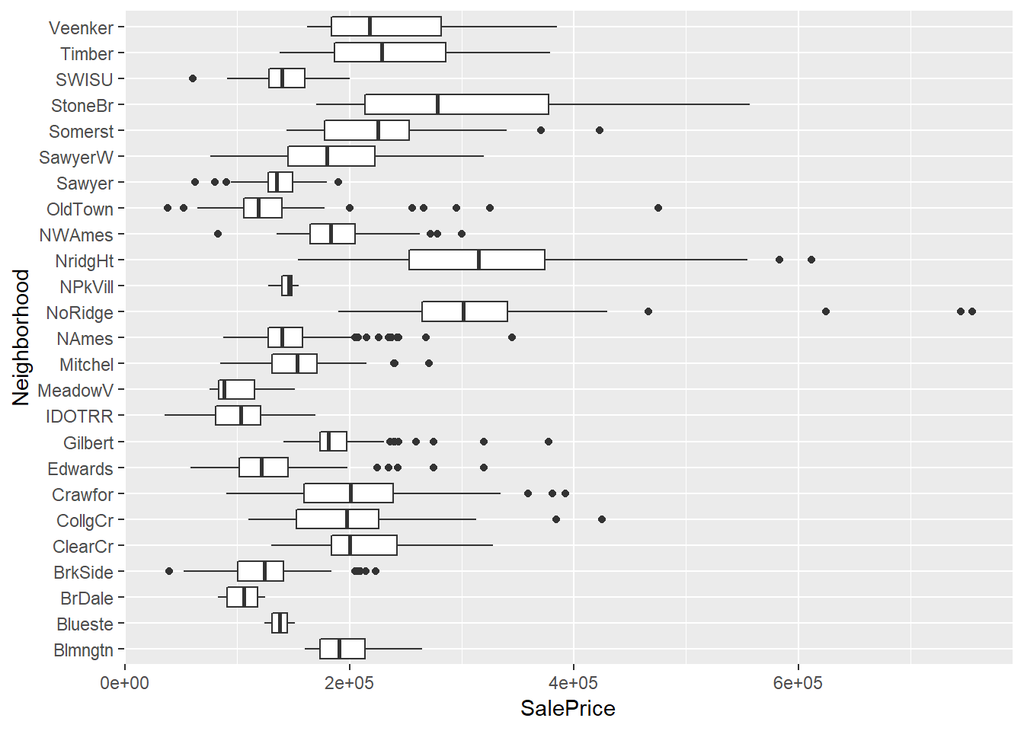

```r
ggplot(train_data) +
  geom_boxplot(aes(Neighborhood, SalePrice)) +
  coord_flip()
```

## Q1: How would you interpret the coefficients on GrLivArea and OverallQual?

Answer: For every unit of `GrLivArea` increased, the price increases by $55.56. For every unit increase of `OverallQual`, the sale price of the house increases by $20,951.

```r
houseprices_lm2 <- lm(formula= SalePrice ~ GrLivArea + OverallQual + Neighborhood, data = train_data)
tidy(houseprices_lm2)
```

```
## # A tibble: 27 x 5
##    term                estimate std.error statistic  p.value
##    <chr>                  <dbl>     <dbl>     <dbl>    <dbl>
##  1 (Intercept)         -34829.   11541.       -3.02 2.59e- 3
##  2 GrLivArea               55.6      2.50     22.2  2.38e-94
##  3 OverallQual          20951.    1162.       18.0  1.24e-65
##  4 NeighborhoodBlueste -30753.   27697.       -1.11 2.67e- 1
##  5 NeighborhoodBrDale  -43359.   12979.       -3.34 8.57e- 4
##  6 NeighborhoodBrkSide -13025.   10450.       -1.25 2.13e- 1
##  7 NeighborhoodClearCr  24576.   11570.        2.12 3.38e- 2
##  8 NeighborhoodCollgCr  11414.    9497.        1.20 2.30e- 1
##  9 NeighborhoodCrawfor  14444.   10502.        1.38 1.69e- 1
## 10 NeighborhoodEdwards -17843.    9986.       -1.79 7.42e- 2
## # ... with 17 more rows
```

```r
glance(houseprices_lm2)
```

```
## # A tibble: 1 x 11
##   r.squared adj.r.squared  sigma statistic p.value    df  logLik    AIC
##       <dbl>         <dbl>  <dbl>     <dbl>   <dbl> <int>   <dbl>  <dbl>
## 1     0.787         0.783 37009.      203.       0    27 -17416. 34887.
## # ... with 3 more variables: BIC <dbl>, deviance <dbl>, df.residual <int>
```

So the feature of OverallQual holds more weight over price increases than GrLivArea.

## Q2: How would you interpret the coefficient on NeighborhoodBrkSide?

Answer: A house in the neighborhood of Brookside, holding square footage and house quality constant, will cost about $13,025 less on average.

## Q4. Are the features practically significant?

Answer: It would seem that looking at `OverallQual` and `GrLivArea` would be conclusive indicators of correlation given the p value but one would have to comb the neighborhood data more diligently as many of the neighborhoods are not good indicators of sales price.

# Exercise 6:

One downside of the linear model is that it is sensitive to unusual values because the distance incorporates a squared term. Fit a linear model to the simulated data below (use y as the target and x as the feature), and look at the resulting coefficients and R-squared. Rerun it about 5-6 times to generate different simulated datasets. What do you notice about the modelâs coefficient on x and the R-squared values?

```r
sim1a <- tibble(
  x = rep(1:10, each = 3),
  y = x * 1.5 + 6 + rt(length(x), df = 2)
)
sim1a
```

```
## # A tibble: 30 x 2
##        x     y
##    <int> <dbl>
##  1     1  6.41
##  2     1  5.93
##  3     1  8.35
##  4     2  9.50
##  5     2  9.57
##  6     2  9.32
##  7     3  9.05
##  8     3 13.6
##  9     3  6.94
## 10     4 13.4
## # ... with 20 more rows
```

```r
(sim.lm <- lm(formula = y ~ x, data = sim1a))
```

```
##
## Call:
## lm(formula = y ~ x, data = sim1a)
##
## Coefficients:
## (Intercept)            x
##       5.851        1.496
```

```r
glance(sim.lm)
```

```
## # A tibble: 1 x 11
##   r.squared adj.r.squared sigma statistic  p.value    df logLik   AIC   BIC
##       <dbl>         <dbl> <dbl>     <dbl>    <dbl> <int>  <dbl> <dbl> <dbl>
## 1     0.913         0.910  1.37      294. 2.18e-16     2  -51.0  108.  112.
## # ... with 2 more variables: deviance <dbl>, df.residual <int>
```

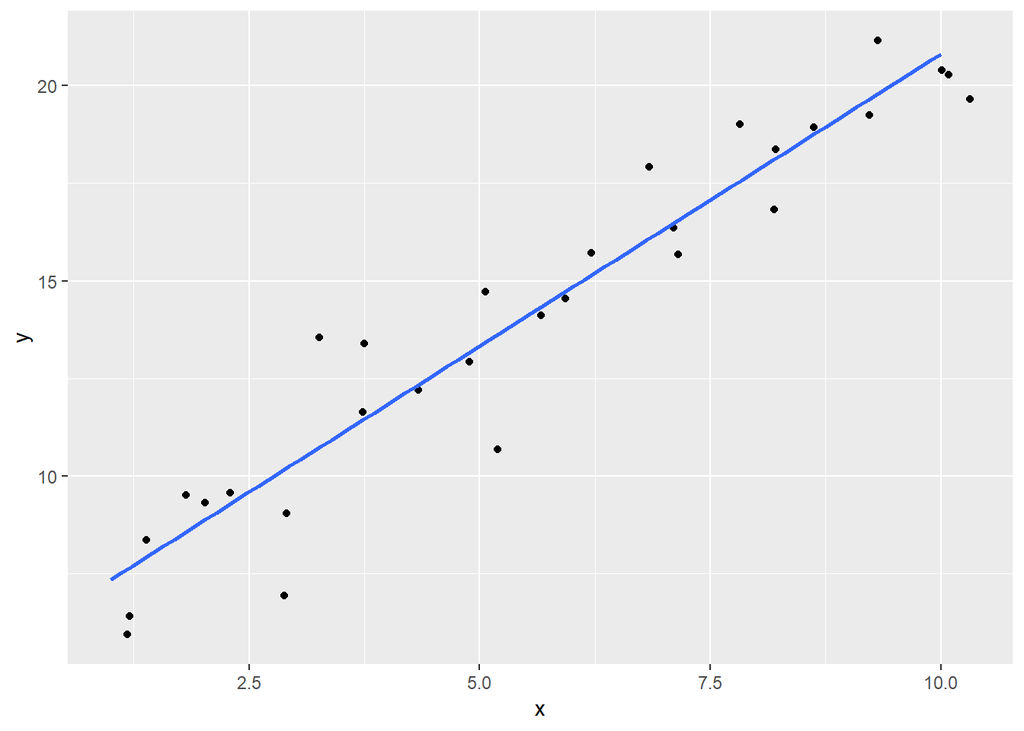

```r
ggplot(sim1a) +
  geom_jitter(aes(x,y)) +
  geom_smooth(aes(x, y), method = "lm", se = FALSE)
```

Answer: By looking at the coefficient on x, it is mostly stable, staying within the 1-2 range. The R squared value however would sometimes get smaller. Looking at a plot, one could see that when there is an outlying value, that will distort the R squared value significantly, making it seem like the model is not a good fit.